# Irrational Capital DeepFin Demo

# Breakout 2: Human Capital Fator (HCF) Ratings

## 1. Introduction

Human Capital Factor (HCF) Ratings are part of an evaluation system that rates a company’s human capital practices by benchmarking against Irrational Capital’s dataset, covering thousands of public companies. HCF ratings include a single HCF overall score, seven dimensional scores, and department-level ratings that are correlated with future equity performance. It can provide insight into a company’s human capital practices or as a Human capital risk monitoring tool, for example. Investors may refer to HCF ratings to illustrate how well a company’s human capital is performing, which is usually intangible, non-comparable, and missed by the traditional financial capital valuation process.

The code section below calculates and outputs 3 sample companies' HCF ratings for different levels.

## 2. Data Feeds

```python
import numpy as np
import pandas as pd
import matplotlib
import matplotlib.pyplot as plt
from irrcap.products import *
from irrcap.loader import load_ec, load_gd, mask_ec_statements
from IPython.display import Image
matplotlib.rc('figure', figsize=(10, 5))
```

```python
private_data = load_ec(ENV='deep-fin', cache=False)
public_data = load_gd(ENV='deep-fin', cache=False)
```

```
INFO:botocore.credentials:Found credentials in shared credentials file: ~/.aws/credentials
```

```python
company_labels = ['X', 'Y', 'Z']
tradeyear = 2019
for idx, ID in enumerate(ID_demo):
    company_data = private_data[(private_data.AssetID == ID) & (private_data.TradeYear == tradeyear)]
    display('Company_'+company_labels[idx]+' data sample size:')
    display(company_data.shape)
```

```
'Company_X data sample size:'
```

```
(8503, 59)
```

```
'Company_Y data sample size:'
```

```
(4265, 59)
```

```
'Company_Z data sample size:'
```

```
(2470, 59)
```

## 3. HCF Ratings Calculation

```python
def convert_to_percentile (df, ID):
    """
    Score Conversion
    Convert the numerical scores into percentile for given ID within a HCFScore dataframe

    Parameters
    ----------
    df : dataframe/series
        dataframe of HCF score results.
    ID : int
        company ID within the df.

    Returns
    -------
    p : float
        percentile rank for company with the ID.

    """
    df['rank'] = df['HCFScore'].rank(ascending=False, method='first')
    r = df[df.AssetID == ID]
    p = 1-r.iloc[0]['rank']/len(df)
    return p
```

```python
def rating_system_conversion (res, df_type = 'frame'):
    """
    Rating Conversion
    Convert the numerical percentiles into letter rating for given dataframe or series

    Parameters
    ----------
    res : dataframe/series
        matrix or vector of percentile ranking results.
    df_type : string, optional
        define the dataframe type. one of the 'frame' or 'series'. The default is 'frame'.

    Returns
    -------
    df : dataframe/series
        dataframe or series for letter ratings.

    """

    df = res.copy()
    if df_type == 'frame':
        for i in range(df.shape[0]):
            for j in range(df.shape[1]):
                percentile = float(df.iloc[i,j])
                if percentile >= 0.8:
                    df.iloc[i,j] = 'A+'
                elif percentile < 0.8 and percentile >= 0.6:
                    df.iloc[i,j] = 'A'
                elif percentile < 0.6 and percentile >= 0.4:
                    df.iloc[i,j] = 'B+'
                elif percentile < 0.4 and percentile >= 0.2:
                    df.iloc[i,j] = 'B'
                elif percentile < 0.2 and percentile >= 0:
                    df.iloc[i,j] = 'C'
                else:
                    df.iloc[i,j] = 'NaN'

    if df_type == 'series':
        for i in range(df.shape[0]):
            percentile = float(df.iloc[i])
            if percentile >= 0.8:
                df.iloc[i] = 'A+'
            elif percentile < 0.8 and percentile >= 0.6:
                df.iloc[i] = 'A'
            elif percentile < 0.6 and percentile >= 0.4:
                df.iloc[i] = 'B+'
            elif percentile < 0.4 and percentile >= 0.2:
                df.iloc[i] = 'B'
            elif percentile < 0.2 and percentile >= 0:
                df.iloc[i] = 'C'
            else:
                df.iloc[i] = 'NaN'
    return df
```

```python
def hcf_ratings (ec, gd, TradeYear, ID, qs, deps):
    """
    HCF Rating Calculation
    Calculates the hcf ratings for a specific company for overall rating, departmental rating, and 7 dimension ratings

    Parameters
    ----------
    ec: dataframe
        private data source
    gd: dataframe
        public data source
    TradeYear: int
        trading year
    ID: int
        the ID of the company that is to perform hcf ratings calculation
    res : dataframe/series
        matrix or vector of percentile ranking results.
    df_type : string, optional
        define the dataframe type. one of the 'frame' or 'series'. The default is 'frame'.

    Returns
    -------
    df : dataframe/series
        dataframe or series for letter ratings.

    """
    res = pd.DataFrame(columns = list(qs.keys()), index = deps)
    ec_noID = ec[ec.AssetID!=ID].copy()
    dep_idx = 1
    for dep in deps:
        for key,q in qs.items():
            if dep == 'All':
                ec_dep = ec[ec.AssetID == ID]
            elif dep == 'Rest':
                ec_dep = ec[(ec.AssetID == ID) & (~ec.DEPARTMENT.isin(deps))]
            else:
                ec_dep = ec[(ec.AssetID == ID) & (ec.DEPARTMENT == dep)]
            ecid = ec_noID.append(ec_dep).copy()
            scores = hcf_score(ecid, gd, TradeYear=TradeYear, ec_q = qs[key])
            p = convert_to_percentile (scores, ID)
            res.loc[dep][key] = p
            print ('HCF rating for department_'+ str(dep_idx) + ' - dimension ' + key +' is completed')
        dep_idx = dep_idx + 1
    return res
```

```python
private_data = mask_ec_statements(private_data, reverse=True)
```

```python
result = {}
for idx, ID in enumerate(ID_demo):
    deps = company_dep_selection(private_data, tradeyear, ID, num_of_dep = 5)
    result[company_labels[idx]] = hcf_ratings (private_data, public_data, TradeYear = tradeyear, ID = ID, qs = qs, deps = deps)
```

[output not shown]

```
HCF rating for department_1 - dimension Overall is completed
```

[output not shown]

```
HCF rating for department_1 - dimension Extrinsic is completed
```

[output not shown]

```
HCF rating for department_1 - dimension Direct_management is completed
```

[output not shown]

```
HCF rating for department_1 - dimension Organizational_alignment is completed
```

[output not shown]

```
HCF rating for department_1 - dimension Engagement is completed
```

[output not shown]

```
HCF rating for department_1 - dimension Innovation is completed
```

[output not shown]

```
HCF rating for department_1 - dimension Organizational_effectiveness is completed
```

[output not shown]

```
HCF rating for department_1 - dimension Emotional_connection is completed
```

[output not shown]

```
HCF rating for department_2 - dimension Overall is completed
```

[output not shown]

```
HCF rating for department_2 - dimension Extrinsic is completed
```

[output not shown]

```
HCF rating for department_2 - dimension Direct_management is completed
```

[output not shown]

```
HCF rating for department_2 - dimension Organizational_alignment is completed
```

[output not shown]

```
HCF rating for department_2 - dimension Engagement is completed
```

[output not shown]

```
HCF rating for department_2 - dimension Innovation is completed
```

[output not shown]

```
HCF rating for department_2 - dimension Organizational_effectiveness is completed
```

[output not shown]

```
HCF rating for department_2 - dimension Emotional_connection is completed
```

[output not shown]

```
HCF rating for department_3 - dimension Overall is completed
```

[output not shown]

```
HCF rating for department_3 - dimension Extrinsic is completed
```

[output not shown]

```
HCF rating for department_3 - dimension Direct_management is completed
```

[output not shown]

```
HCF rating for department_3 - dimension Organizational_alignment is completed
```

[output not shown]

```
HCF rating for department_3 - dimension Engagement is completed
```

[output not shown]

```
HCF rating for department_3 - dimension Innovation is completed
```

[output not shown]

```
HCF rating for department_3 - dimension Organizational_effectiveness is completed
```

[output not shown]

```
HCF rating for department_3 - dimension Emotional_connection is completed
```

[output not shown]

```
HCF rating for department_4 - dimension Overall is completed
```

[output not shown]

```
HCF rating for department_4 - dimension Extrinsic is completed
```

[output not shown]

```
HCF rating for department_4 - dimension Direct_management is completed
```

[output not shown]

```
HCF rating for department_4 - dimension Organizational_alignment is completed
```

[output not shown]

```
HCF rating for department_4 - dimension Engagement is completed
```

[output not shown]

```
HCF rating for department_4 - dimension Innovation is completed
```

[output not shown]

```
HCF rating for department_4 - dimension Organizational_effectiveness is completed
```

[output not shown]

```
HCF rating for department_4 - dimension Emotional_connection is completed
```

[output not shown]

```
HCF rating for department_5 - dimension Overall is completed
```

[output not shown]

```
HCF rating for department_5 - dimension Extrinsic is completed
```

[output not shown]

```
HCF rating for department_5 - dimension Direct_management is completed
```

[output not shown]

```
HCF rating for department_5 - dimension Organizational_alignment is completed
```

[output not shown]

```
HCF rating for department_5 - dimension Engagement is completed
```

[output not shown]

```
HCF rating for department_5 - dimension Innovation is completed
```

[output not shown]

```
HCF rating for department_5 - dimension Organizational_effectiveness is completed
```

[output not shown]

```
HCF rating for department_5 - dimension Emotional_connection is completed
```

[output not shown]

```
HCF rating for department_6 - dimension Overall is completed
```

[output not shown]

```
HCF rating for department_6 - dimension Extrinsic is completed
```

[output not shown]

```
HCF rating for department_6 - dimension Direct_management is completed
```

[output not shown]

```
HCF rating for department_6 - dimension Organizational_alignment is completed
```

[output not shown]

```
HCF rating for department_6 - dimension Engagement is completed
```

[output not shown]

```
HCF rating for department_6 - dimension Innovation is completed
```

[output not shown]

```
HCF rating for department_6 - dimension Organizational_effectiveness is completed
```

[output not shown]

```
HCF rating for department_6 - dimension Emotional_connection is completed
```

[output not shown]

```
HCF rating for department_7 - dimension Overall is completed
```

[output not shown]

```
HCF rating for department_7 - dimension Extrinsic is completed
```

[output not shown]

```
HCF rating for department_7 - dimension Direct_management is completed
```

[output not shown]

```
HCF rating for department_7 - dimension Organizational_alignment is completed
```

[output not shown]

```
HCF rating for department_7 - dimension Engagement is completed
```

[output not shown]

```
HCF rating for department_7 - dimension Innovation is completed
```

[output not shown]

```
HCF rating for department_7 - dimension Organizational_effectiveness is completed
```

[output not shown]

```
HCF rating for department_7 - dimension Emotional_connection is completed
```

[output not shown]

```
HCF rating for department_1 - dimension Overall is completed
```

[output not shown]

```
HCF rating for department_1 - dimension Extrinsic is completed
```

[output not shown]

```
HCF rating for department_1 - dimension Direct_management is completed
```

[output not shown]

```
HCF rating for department_1 - dimension Organizational_alignment is completed
```

[output not shown]

```
HCF rating for department_1 - dimension Engagement is completed
```

[output not shown]

```
HCF rating for department_1 - dimension Innovation is completed
```

[output not shown]

```
HCF rating for department_1 - dimension Organizational_effectiveness is completed
```

[output not shown]

```
HCF rating for department_1 - dimension Emotional_connection is completed
```

[output not shown]

```
HCF rating for department_2 - dimension Overall is completed
```

[output not shown]

```
HCF rating for department_2 - dimension Extrinsic is completed
```

[output not shown]

```
HCF rating for department_2 - dimension Direct_management is completed
```

[output not shown]

```
HCF rating for department_2 - dimension Organizational_alignment is completed
```

[output not shown]

```
HCF rating for department_2 - dimension Engagement is completed
```

[output not shown]

```
HCF rating for department_2 - dimension Innovation is completed
```

[output not shown]

```
HCF rating for department_2 - dimension Organizational_effectiveness is completed
```

[output not shown]

```
HCF rating for department_2 - dimension Emotional_connection is completed
```

[output not shown]

```
HCF rating for department_3 - dimension Overall is completed
```

[output not shown]

```
HCF rating for department_3 - dimension Extrinsic is completed
```

[output not shown]

```
HCF rating for department_3 - dimension Direct_management is completed
```

[output not shown]

```
HCF rating for department_3 - dimension Organizational_alignment is completed
```

[output not shown]

```
HCF rating for department_3 - dimension Engagement is completed
```

[output not shown]

```
HCF rating for department_3 - dimension Innovation is completed
```

[output not shown]

```
HCF rating for department_3 - dimension Organizational_effectiveness is completed
```

[output not shown]

```
HCF rating for department_3 - dimension Emotional_connection is completed
```

[output not shown]

```
HCF rating for department_4 - dimension Overall is completed
```

[output not shown]

```
HCF rating for department_4 - dimension Extrinsic is completed
```

[output not shown]

```
HCF rating for department_4 - dimension Direct_management is completed
```

[output not shown]

```
HCF rating for department_4 - dimension Organizational_alignment is completed
```

[output not shown]

```
HCF rating for department_4 - dimension Engagement is completed
```

[output not shown]

```
HCF rating for department_4 - dimension Innovation is completed
```

[output not shown]

```
HCF rating for department_4 - dimension Organizational_effectiveness is completed
```

[output not shown]

```
HCF rating for department_4 - dimension Emotional_connection is completed
```

[output not shown]

```
HCF rating for department_5 - dimension Overall is completed
```

[output not shown]

```
HCF rating for department_5 - dimension Extrinsic is completed
```

[output not shown]

```
HCF rating for department_5 - dimension Direct_management is completed
```

[output not shown]

```
HCF rating for department_5 - dimension Organizational_alignment is completed
```

[output not shown]

```
HCF rating for department_5 - dimension Engagement is completed
```

[output not shown]

```
HCF rating for department_5 - dimension Innovation is completed
```

[output not shown]

```
HCF rating for department_5 - dimension Organizational_effectiveness is completed
```

[output not shown]

```
HCF rating for department_5 - dimension Emotional_connection is completed
```

[output not shown]

```
HCF rating for department_6 - dimension Overall is completed
```

[output not shown]

```
HCF rating for department_6 - dimension Extrinsic is completed
```

[output not shown]

```
HCF rating for department_6 - dimension Direct_management is completed
```

[output not shown]

```
HCF rating for department_6 - dimension Organizational_alignment is completed
```

[output not shown]

```
HCF rating for department_6 - dimension Engagement is completed
```

[output not shown]

```
HCF rating for department_6 - dimension Innovation is completed
```

[output not shown]

```
HCF rating for department_6 - dimension Organizational_effectiveness is completed
```

[output not shown]

```
HCF rating for department_6 - dimension Emotional_connection is completed
```

[output not shown]

```
HCF rating for department_1 - dimension Overall is completed
```

[output not shown]

```
HCF rating for department_1 - dimension Extrinsic is completed
```

[output not shown]

```
HCF rating for department_1 - dimension Direct_management is completed
```

[output not shown]

```
HCF rating for department_1 - dimension Organizational_alignment is completed
```

[output not shown]

```
HCF rating for department_1 - dimension Engagement is completed
```

[output not shown]

```
HCF rating for department_1 - dimension Innovation is completed
```

[output not shown]

```
HCF rating for department_1 - dimension Organizational_effectiveness is completed
```

[output not shown]

```
HCF rating for department_1 - dimension Emotional_connection is completed
```

[output not shown]

```
HCF rating for department_2 - dimension Overall is completed
```

[output not shown]

```
HCF rating for department_2 - dimension Extrinsic is completed
```

[output not shown]

```
HCF rating for department_2 - dimension Direct_management is completed
```

[output not shown]

```
HCF rating for department_2 - dimension Organizational_alignment is completed
```

[output not shown]

```
HCF rating for department_2 - dimension Engagement is completed
```

[output not shown]

```
HCF rating for department_2 - dimension Innovation is completed
```

[output not shown]

```
HCF rating for department_2 - dimension Organizational_effectiveness is completed
```

[output not shown]

```
HCF rating for department_2 - dimension Emotional_connection is completed
```

[output not shown]

```
HCF rating for department_3 - dimension Overall is completed
```

[output not shown]

```
HCF rating for department_3 - dimension Extrinsic is completed
```

[output not shown]

```
HCF rating for department_3 - dimension Direct_management is completed
```

[output not shown]

```
HCF rating for department_3 - dimension Organizational_alignment is completed
```

[output not shown]

```
HCF rating for department_3 - dimension Engagement is completed
```

[output not shown]

```
HCF rating for department_3 - dimension Innovation is completed
```

[output not shown]

```
HCF rating for department_3 - dimension Organizational_effectiveness is completed
```

[output not shown]

```
HCF rating for department_3 - dimension Emotional_connection is completed
```

[output not shown]

```
HCF rating for department_4 - dimension Overall is completed
```

[output not shown]

```
HCF rating for department_4 - dimension Extrinsic is completed
```

[output not shown]

```
HCF rating for department_4 - dimension Direct_management is completed
```

[output not shown]

```
HCF rating for department_4 - dimension Organizational_alignment is completed
```

[output not shown]

```
HCF rating for department_4 - dimension Engagement is completed
```

[output not shown]

```
HCF rating for department_4 - dimension Innovation is completed
```

[output not shown]

```
HCF rating for department_4 - dimension Organizational_effectiveness is completed
```

[output not shown]

```
HCF rating for department_4 - dimension Emotional_connection is completed
```

[output not shown]

```
HCF rating for department_5 - dimension Overall is completed
```

[output not shown]

```
HCF rating for department_5 - dimension Extrinsic is completed
```

[output not shown]

```
HCF rating for department_5 - dimension Direct_management is completed
```

[output not shown]

```
HCF rating for department_5 - dimension Organizational_alignment is completed
```

[output not shown]

```
HCF rating for department_5 - dimension Engagement is completed
```

[output not shown]

```
HCF rating for department_5 - dimension Innovation is completed
```

[output not shown]

```
HCF rating for department_5 - dimension Organizational_effectiveness is completed
```

[output not shown]

```
HCF rating for department_5 - dimension Emotional_connection is completed
```

[output not shown]

```
HCF rating for department_6 - dimension Overall is completed
```

[output not shown]

```
HCF rating for department_6 - dimension Extrinsic is completed
```

[output not shown]

```
HCF rating for department_6 - dimension Direct_management is completed
```

[output not shown]

```
HCF rating for department_6 - dimension Organizational_alignment is completed
```

[output not shown]

```
HCF rating for department_6 - dimension Engagement is completed
```

[output not shown]

```
HCF rating for department_6 - dimension Innovation is completed
```

[output not shown]

```
HCF rating for department_6 - dimension Organizational_effectiveness is completed
```

[output not shown]

```
HCF rating for department_6 - dimension Emotional_connection is completed
```

```python
def mask_department(df):
    idx = range (0, len(df.index))
    department_label = ['Department_%i' % i for i in idx]
    department_label[0] = 'Company'
    df.index = department_label
    return df
```

```python
ratings = {}
for key, res in result.items():
    res = mask_department(res)
    ratings[key] = rating_system_conversion(res)
    display('Company_' + key + ' :')
    display(ratings[key])
```

```
'Company_X :'
```

|  | Overall | Extrinsic | Direct_management | Organizational_alignment | Engagement | Innovation | Organizational_effectiveness | Emotional_connection |
| --- | --- | --- | --- | --- | --- | --- | --- | --- |
| Company | B | B | B | B | B | B | B | B |
| Department_1 | B | B | B | B | B | B+ | B | B |
| Department_2 | B | B | B | B | B | B | B | B |
| Department_3 | B | C | B | B | B | B | B | B |
| Department_4 | C | C | C | C | C | C | C | C |
| Department_5 | C | C | B | C | C | C | C | C |
| Department_6 | B | B | B | B | B | B+ | B+ | B |

```
'Company_Y :'
```

|  | Overall | Extrinsic | Direct_management | Organizational_alignment | Engagement | Innovation | Organizational_effectiveness | Emotional_connection |
| --- | --- | --- | --- | --- | --- | --- | --- | --- |
| Company | A | A | A | A | B+ | A | B+ | B |
| Department_1 | A | A+ | A | B+ | A | A | A | B+ |
| Department_2 | B+ | A | B+ | B+ | B+ | A | B+ | B |
| Department_3 | A | A+ | A | B+ | B+ | A | B+ | B |
| Department_4 | A | A | A | A | A | A | B+ | B |
| Department_5 | A | A | A | A | B+ | A | B+ | B |

```
'Company_Z :'
```

|  | Overall | Extrinsic | Direct_management | Organizational_alignment | Engagement | Innovation | Organizational_effectiveness | Emotional_connection |
| --- | --- | --- | --- | --- | --- | --- | --- | --- |
| Company | A+ | A | A | A+ | A+ | A+ | A+ | A |
| Department_1 | A+ | A | A+ | A+ | A+ | A+ | A+ | A+ |
| Department_2 | A+ | B | A+ | A+ | A | A+ | A+ | B+ |
| Department_3 | A | A+ | B+ | A+ | A | A+ | A+ | A |
| Department_4 | A+ | B+ | A | A+ | A+ | A+ | A+ | A+ |
| Department_5 | A+ | A | A | A+ | A+ | A+ | A+ | A |

### 3.1 HCF Overall Score

Single HCF Score that calculated by all questions using HCF algorithm and then mapped to HCF rating system.

```python
for key, rating in ratings.items():
    res_overall = rating.iloc[0,0]
    print('Company_' + key + ' : ' + res_overall)
```

```
Company_X : B
Company_Y : A
Company_Z : A+
```

#### Human Capital Factor - Top Quintile HCF Score vs S&P 500

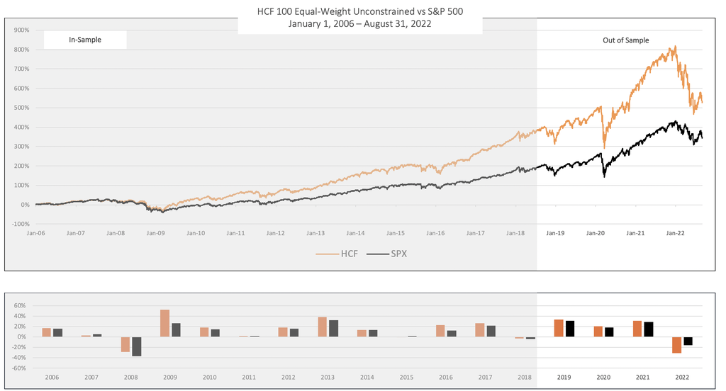

```python
Image(filename='hcf_overall_top_quintile_backtesting.png')
```

### 3.2 HCF Dimension Score

HCF Dimension Score is HCF score generated by subgroup of questions.

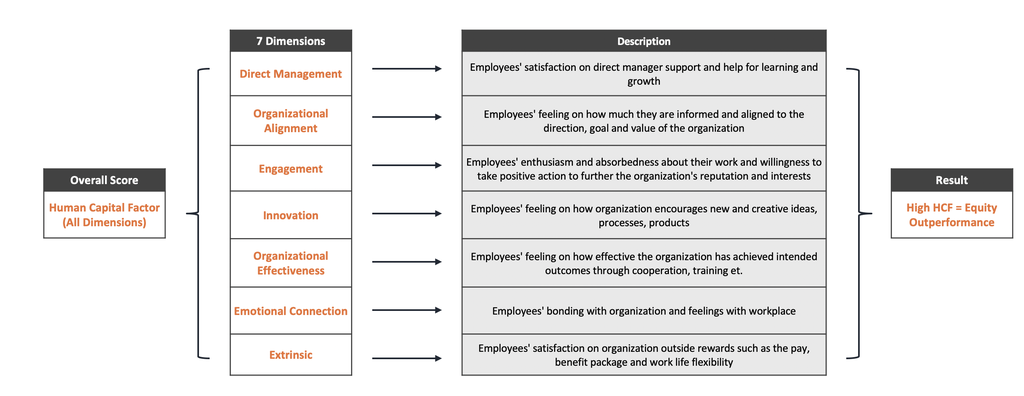

```python
Image(filename='7_dimension.png')
```

#### Quantified cultural factors outperform individually & in aggregate – Top Quintile (A+)

| Dimension | Top vs. Bottom Quintile | Top Quintile vs. Benchmark |
| --- | --- | --- |
| Direct Managerial Relationships | +5.73% | +3.08% |
| Emotional Connection | +3.57% | +2.51% |
| Engagement & Leadership | +3.85% | +2.94% |
| Extrinsic Motivation | +3.15% | +3.02% |
| Innovation | +5.97% | +4.20% |
| Organizational Alignment | +4.66% | +3.04% |
| Organizational Effectiveness | +6.33% | +4.12% |

```python
for key, rating in ratings.items():
    rating_dimension = rating.iloc[0,1:]
    display('Company_' + key + ' :')
    display(rating_dimension)
```

```
'Company_X :'
```

```
Extrinsic                       B
Direct_management               B
Organizational_alignment        B
Engagement                      B
Innovation                      B
Organizational_effectiveness    B
Emotional_connection            B
Name: Company, dtype: object
```

```
'Company_Y :'
```

```
Extrinsic                        A
Direct_management                A
Organizational_alignment         A
Engagement                      B+
Innovation                       A
Organizational_effectiveness    B+
Emotional_connection             B
Name: Company, dtype: object
```

```
'Company_Z :'
```

```
Extrinsic                        A
Direct_management                A
Organizational_alignment        A+
Engagement                      A+
Innovation                      A+
Organizational_effectiveness    A+
Emotional_connection             A
Name: Company, dtype: object
```

```python
def radar_plot(res_dimension, values_overall, company_label):
    labels = res_dimension.index.tolist()
    values = res_dimension.tolist()
    num_vars = len(labels)
    angles = np.linspace(0, 2 * np.pi, num_vars, endpoint=False).tolist()
    values += values[:1]
    angles += angles[:1]
    labels += labels[:1]

    fig, ax = plt.subplots(figsize=(6, 6), subplot_kw=dict(polar=True))

    ax.plot(angles, values_overall, color='red', linewidth=1, label= 'Company Overall Score')
    ax.fill(angles, values_overall, color='red', alpha=0.15)

    ax.plot(angles, values, color='green', linewidth=1, label= 'Dimension Score')
    ax.fill(angles, values, color='green', alpha=0.45)

    ax.set_theta_offset(np.pi / 2)
    ax.set_theta_direction(-1)
    ax.set_thetagrids(np.degrees(angles), labels)

    for label, angle in zip(ax.get_xticklabels(), angles):
      if angle in (0, np.pi):
        label.set_horizontalalignment('center')
      elif 0 < angle < np.pi:
        label.set_horizontalalignment('left')
      else:
        label.set_horizontalalignment('right')

    ax.set_ylim(0, 1)
    ax.set_rlabel_position(180 / num_vars)

    ax.tick_params(colors='#222222')
    ax.tick_params(axis='y', labelsize=8)
    ax.grid(color='#AAAAAA')
    ax.spines['polar'].set_color('#222222')
    ax.set_facecolor('#FAFAFA')

    ax.set_title('HCF 7-Dimension Profile for Company_'+company_label, y=1.08)

    ax.legend(loc='upper right', bbox_to_anchor=(1.3, 1.1))

    plt.show()
```

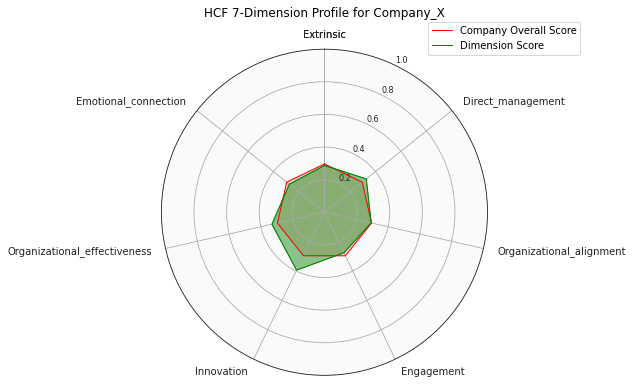

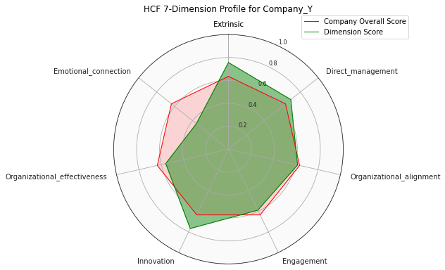

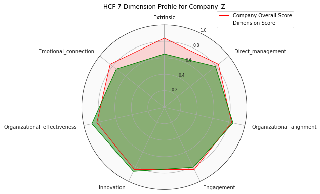

```python
for key, res in result.items():
    res_dimension = res.iloc[0,1:]
    comp_overall = res.iloc[0,0]
    values_overall = [comp_overall] * (len(res_dimension)+1)
    radar_plot(res_dimension, values_overall, company_label = key)
```

### 3.3 HCF Department Score

For each department, the respective HCF overall and dimension score can be calculated.

#### 3.3.1 HCF Department Overall Score

```python
for key, rating in ratings.items():
    rating_dep_overall = rating.iloc[1:,0]
    display('Company_' + key + ' :')
    display(rating_dep_overall)
```

```
'Company_X :'
```

```
Department_1    B
Department_2    B
Department_3    B
Department_4    C
Department_5    C
Department_6    B
Name: Overall, dtype: object
```

```
'Company_Y :'
```

```
Department_1     A
Department_2    B+
Department_3     A
Department_4     A
Department_5     A
Name: Overall, dtype: object
```

```
'Company_Z :'
```

```
Department_1    A+
Department_2    A+
Department_3     A
Department_4    A+
Department_5    A+
Name: Overall, dtype: object
```

```python
def department_overall_plot(company_label, res):
    res_dep_overall = res.iloc[1:,0]
    department = res_dep_overall.index.to_list()
    dep_ratings = res_dep_overall.to_list()
    comp_overall = res.iloc[0,0]
    values_overall = [comp_overall] * (len(res_dep_overall))
    dep_diff = dep_ratings - comp_overall
    plt.figure(figsize=(10,6))
    plt.barh(department, dep_diff, color="g", alpha = 0.5)
    plt.xlabel ('HCF departmental rating vs HCF company overall (Company_'+company_label+')', fontsize=12)
    plt.xlim([-0.3, 0.3])
    plt.ylabel ('Department', fontsize=12)
    plt.show()
```

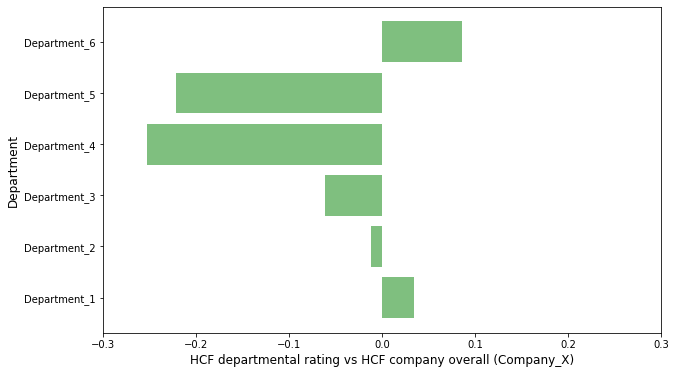

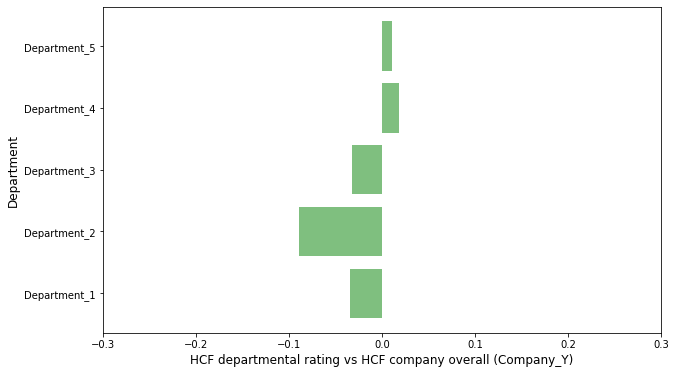

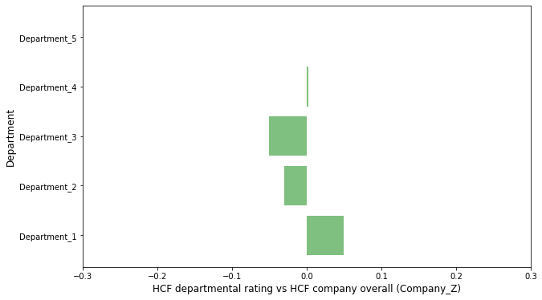

```python
for key, r in result.items():
    department_overall_plot(key, res = r)
```

#### 3.3.2 HCF Department Dimension Score

```python
for key, rating in ratings.items():
    rating_dep = rating.iloc[1:, 1:]
    display('Company_'+key+' :')
    display(rating_dep)
```

```
'Company_X :'
```

|  | Extrinsic | Direct_management | Organizational_alignment | Engagement | Innovation | Organizational_effectiveness | Emotional_connection |
| --- | --- | --- | --- | --- | --- | --- | --- |
| Department_1 | B | B | B | B | B+ | B | B |
| Department_2 | B | B | B | B | B | B | B |
| Department_3 | C | B | B | B | B | B | B |
| Department_4 | C | C | C | C | C | C | C |
| Department_5 | C | B | C | C | C | C | C |
| Department_6 | B | B | B | B | B+ | B+ | B |

```
'Company_Y :'
```

|  | Extrinsic | Direct_management | Organizational_alignment | Engagement | Innovation | Organizational_effectiveness | Emotional_connection |
| --- | --- | --- | --- | --- | --- | --- | --- |
| Department_1 | A+ | A | B+ | A | A | A | B+ |
| Department_2 | A | B+ | B+ | B+ | A | B+ | B |
| Department_3 | A+ | A | B+ | B+ | A | B+ | B |
| Department_4 | A | A | A | A | A | B+ | B |
| Department_5 | A | A | A | B+ | A | B+ | B |

```
'Company_Z :'
```

|  | Extrinsic | Direct_management | Organizational_alignment | Engagement | Innovation | Organizational_effectiveness | Emotional_connection |
| --- | --- | --- | --- | --- | --- | --- | --- |
| Department_1 | A | A+ | A+ | A+ | A+ | A+ | A+ |
| Department_2 | B | A+ | A+ | A | A+ | A+ | B+ |
| Department_3 | A+ | B+ | A+ | A | A+ | A+ | A |
| Department_4 | B+ | A | A+ | A+ | A+ | A+ | A+ |
| Department_5 | A | A | A+ | A+ | A+ | A+ | A |

```python
def heatmap(data, row_labels, col_labels, ax=None,
            cbar_kw={}, cbarlabel="", **kwargs):
    """
    Create a heatmap from a numpy array and two lists of labels.

    Parameters
    ----------
    data
        A 2D numpy array of shape (M, N).
    row_labels
        A list or array of length M with the labels for the rows.
    col_labels
        A list or array of length N with the labels for the columns.
    ax
        A `matplotlib.axes.Axes` instance to which the heatmap is plotted.  If
        not provided, use current axes or create a new one.  Optional.
    cbar_kw
        A dictionary with arguments to `matplotlib.Figure.colorbar`.  Optional.
    cbarlabel
        The label for the colorbar.  Optional.
    **kwargs
        All other arguments are forwarded to `imshow`.
    """

    if not ax:
        ax = plt.gca()

    # Plot the heatmap
    im = ax.imshow(data, **kwargs)

    cbar = ax.figure.colorbar(im, ax=ax, **cbar_kw)
    cbar.ax.set_ylabel(cbarlabel, rotation=-90, va="bottom")

    ax.set_xticks(np.arange(data.shape[1]), labels=col_labels)
    ax.set_yticks(np.arange(data.shape[0]), labels=row_labels)

    ax.tick_params(top=True, bottom=False,
                   labeltop=True, labelbottom=False)

    plt.setp(ax.get_xticklabels(), rotation=-30, ha="right",
             rotation_mode="anchor")

    ax.spines[:].set_visible(False)

    ax.set_xticks(np.arange(data.shape[1]+1)-.5, minor=True)
    ax.set_yticks(np.arange(data.shape[0]+1)-.5, minor=True)
    ax.grid(which="minor", color="w", linestyle='-', linewidth=3)
    ax.tick_params(which="minor", bottom=False, left=False)

    return im, cbar


def annotate_heatmap(im, data=None, valfmt="{x:.2f}",
                     textcolors=("black", "white"),
                     threshold=None, **textkw):
    """
    A function to annotate a heatmap.

    Parameters
    ----------
    im
        The AxesImage to be labeled.
    data
        Data used to annotate.  If None, the image's data is used.  Optional.
    valfmt
        The format of the annotations inside the heatmap.  This should either
        use the string format method, e.g. "$ {x:.2f}", or be a
        `matplotlib.ticker.Formatter`.  Optional.
    textcolors
        A pair of colors.  The first is used for values below a threshold,
        the second for those above.  Optional.
    threshold
        Value in data units according to which the colors from textcolors are
        applied.  If None (the default) uses the middle of the colormap as
        separation.  Optional.
    **kwargs
        All other arguments are forwarded to each call to `text` used to create
        the text labels.
    """

    if not isinstance(data, (list, np.ndarray)):
        data = im.get_array()

    if threshold is not None:
        threshold = im.norm(threshold)
    else:
        threshold = im.norm(data.max())/2.

    kw = dict(horizontalalignment="center",
              verticalalignment="center")
    kw.update(textkw)

    if isinstance(valfmt, str):
        valfmt = matplotlib.ticker.StrMethodFormatter(valfmt)

    texts = []
    for i in range(data.shape[0]):
        for j in range(data.shape[1]):
            kw.update(color=textcolors[int(im.norm(data[i, j]) > threshold)])
            text = im.axes.text(j, i, valfmt(data[i, j], None), **kw)
            texts.append(text)

    return texts
```

```python
def department_dimension_plot (res, company_label):
    res_dep = res.iloc[1:, 1:]
    plot_data = res_dep.to_numpy().astype(float)
    col_label = res_dep.columns.to_list()
    row_label = res_dep.index.to_list()
    fig, ax = plt.subplots()
    im, cbar = heatmap(plot_data, row_label, col_label, ax=ax,
                       cmap="RdYlGn", cbarlabel="HCF Percentile")
    texts = annotate_heatmap(im, valfmt="{x:.1f}")
    plt.title ('HCF department-dimension ratings for company_' + company_label)
    plt.show()
```

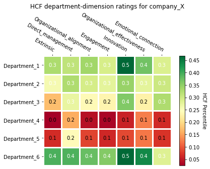

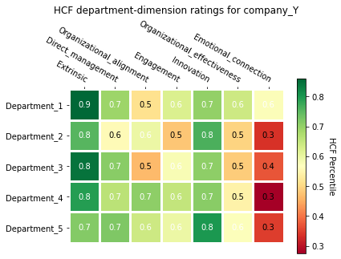

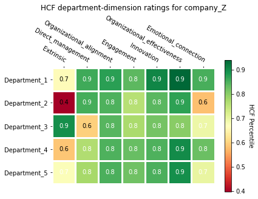

```python
for key, r in result.items():
    department_dimension_plot(r, key)
```